# Deploy and monitor a machine learning workflow for Image Classification

### Testing and Evaluation

Do several step function invokations using data from the `./test` folder. This process should give you confidence that the workflow both *succeeds* AND *fails* as expected. In addition, SageMaker Model Monitor will generate recordings of your data and inferences which we can visualize.

Here's a function that can help you generate test inputs for your invokations:

```python
import random
import boto3
import json


def generate_test_case():
    # Setup s3 in boto3
    s3 = boto3.resource('s3')

    # Randomly pick from sfn or test folders in our bucket
    objects = s3.Bucket(bucket).objects.filter(Prefix="test")

    # Grab any random object key from that folder!
    obj = random.choice([x.key for x in objects])

    return json.dumps({
        "image_data": "",
        "s3_bucket": bucket,
        "s3_key": obj
    })
generate_test_case()
```

```
'{"image_data": "", "s3_bucket": "sagemaker-us-east-1-503271025315", "s3_key": "test/minibike_s_000947.png"}'
```

In the Step Function dashboard for your new function, you can create new executions and copy in the generated test cases. Do several executions so that you can generate data you can evaluate and visualize.

Once you've done several executions, let's visualize the record of our inferences. Pull in the JSONLines data from your inferences like so:

```python
from sagemaker.s3 import S3Downloader

# In S3 your data will be saved to a datetime-aware path
# Find a path related to a datetime you're interested in
data_path = "s3://sagemaker-us-east-1-503271025315/data_capture/image-classification-2024-08-17-19-38-20-598/AllTraffic/2024/08/21/02/21-40-430-462d4ff5-83de-4195-b4bc-1998e2b44bf0.jsonl" ## TODO: fill in the path to your captured data
data_path = "s3://sagemaker-us-east-1-503271025315/data_capture/image-classification-2024-08-17-19-38-20-598/AllTraffic/2024/08/21/02/05-35-020-6f10e974-3d0d-41ae-b8dc-c5f757dace6e.jsonl" ## TODO: fill in the path to your captured data
data_path = "s3://sagemaker-us-east-1-503271025315/data_capture/image-classification-2024-08-17-19-38-20-598/AllTraffic/2024/08/21/02/41-57-730-fcc942f1-99d3-43a5-8055-788708f5da5d.jsonl" ## TODO: fill in the path to your captured data
data_path = "s3://sagemaker-us-east-1-503271025315/data_capture/image-classification-2024-08-17-19-38-20-598/AllTraffic/2024/08/21/03/11-26-098-3e202cb5-7eae-49de-a4a9-d8c50664dd77.jsonl" ## TODO: fill in the path to your captured data
data_path = "s3://sagemaker-us-east-1-503271025315/data_capture/image-classification-2024-08-17-19-38-20-598/AllTraffic/2024/08/21/03/18-40-448-da612901-ebcc-4ace-bb7c-900b00b63d88.jsonl" ## TODO: fill in the path to your captured data
data_path = "s3://sagemaker-us-east-1-503271025315/data_capture/image-classification-2024-08-17-19-38-20-598/AllTraffic/2024/08/21/06/01-17-147-c0db76db-8785-4f2e-91ef-dceaaf2975ee.jsonl" ## TODO: fill in the path to your captured data
data_path = "s3://sagemaker-us-east-1-503271025315/data_capture/image-classification-2024-08-17-19-38-20-598/AllTraffic/2024/08/21/06/04-39-123-9c3a1d91-88d4-4bf9-9e3e-b40fc2af7d30.jsonl" ## TODO: fill in the path to your captured data

S3Downloader.download(data_path, "captured_data")

# Feel free to repeat this multiple times and pull in more data
```

```
['captured_data/04-39-123-9c3a1d91-88d4-4bf9-9e3e-b40fc2af7d30.jsonl']
```

The data are in JSONLines format, where multiple valid JSON objects are stacked on top of eachother in a single `jsonl` file. We'll import an open-source library, `jsonlines` that was purpose built for parsing this format.

```python
!pip install jsonlines
import jsonlines
```

```
Downloading jsonlines-4.0.0-py3-none-any.whl (8.7 kB)
WARNING: Running pip as the 'root' user can result in broken permissions and conflicting behaviour with the system package manager. It is recommended to use a virtual environment instead: https://pip.pypa.io/warnings/venv
```

Now we can extract the data from each of the source files:

```python
import os

# List the file names we downloaded
file_handles = []
for root, subFolders, files in os.walk("./captured_data"):
    if files:
        file_handles += [root + '/' + file for file in files]

# Dump all the data into an array
json_data = []
for jsonl in file_handles:
    with jsonlines.open(jsonl) as f:
        for dict_line in f.iter():
            json_data.append(dict_line)
```

The data should now be a list of dictionaries, with significant nesting. We'll give you an example of some code that grabs data out of the objects and visualizes it:

```python
# Define how we'll get our data
def simple_getter(obj):
    inferences = obj["captureData"]["endpointOutput"]["data"]
    timestamp = obj["eventMetadata"]["inferenceTime"]
    return json.loads(inferences), timestamp

simple_getter(json_data[0])
```

```
([0.9962582588195801, 0.003741796361282468], '2024-08-21T02:21:40Z')
```

Finally, here's an example of a visualization you can build with this data. In this last part, you will take some time and build your own - the captured data has the input images, the resulting inferences, and the timestamps.

### Todo: build your own visualization

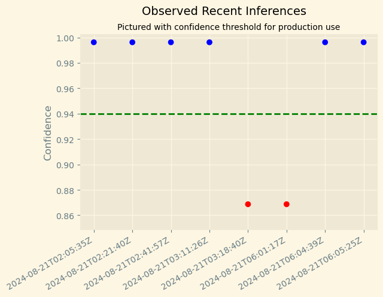

```python
# Change the threshold value to the same value you used before.
THRESHOLD = 0.93

data_points = []
for obj in json_data:
    inference, timestamp = simple_getter(obj)

    data_points.append((timestamp, max(inference)))

# Sort data by timestamp.
data_points.sort()

# Populate the data for the x and y axis
x = [p[0] for p in data_points]
y = [p[1] for p in data_points]

# Todo: here is an visualization example, take some time to build another visual that helps monitor the result
# Plot the data
plt.scatter(x, y, c=['r' if k < THRESHOLD else 'b' for k in y ])
plt.axhline(y=0.94, color='g', linestyle='--')
plt.ylim(bottom=min(y) - 0.02) # New Fady

# Add labels
plt.ylabel("Confidence")
plt.suptitle("Observed Recent Inferences", size=14)
plt.title("Pictured with confidence threshold for production use", size=10)

# Give it some pizzaz!
plt.style.use("Solarize_Light2")
plt.gcf().autofmt_xdate()
```

### Congratulations!

You've reached the end of the project. In this project you created an event-drivent ML workflow that can be incorporated into the Scones Unlimited production architecture. You used the SageMaker Estimator API to deploy your SageMaker Model and Endpoint, and you used AWS Lambda and Step Functions to orchestrate your ML workflow. Using SageMaker Model Monitor, you instrumented and observed your Endpoint, and at the end of the project you built a visualization to help stakeholders understand the performance of the Endpoint over time. If you're up for it, you can even go further with these stretch goals:

- Extend your workflow to incorporate more classes: the CIFAR dataset includes other vehicles that Scones Unlimited can identify with this model.
- Modify your event driven workflow: can you rewrite your Lambda functions so that the workflow can process multiple image inputs in parallel? Can the Step Function "fan out" to accomodate this new workflow?
- Consider the test data generator we provided for you. Can we use it to create a "dummy data" generator, to simulate a continuous stream of input data? Or a big paralell load of data?
- What if we want to get notified every time our step function errors out? Can we use the Step Functions visual editor in conjunction with a service like SNS to accomplish this? Try it out!